# 家中空气质量报告

编写者: Lina Ang

报告制作日期: 2025-04-15

## 简介

家庭编号: **PC198_PC199**

本报告概述了您家中的空气质量情况，聚焦于您家中**可吸入颗粒物 (PM<sub>2.5</sub>)** 的测量数据水平。您家中的 PM<sub>2.5</sub> 测量数据水平是根据每立方米空气中记录的细颗粒物（PM<sub>2.5</sub>）数量（颗粒数）计算得出的。我们将通过描述性统计数据和可视化图表展示相关发现。根据世界卫生组织（WHO）2021 年空气质量指南，PM<sub>2.5</sub> 的24小时平均浓度不应超过 15 微克/立方米。如需了解更多关于世卫组织空气质量指南的信息，请点击[链接](https://www.who.int/news-room/feature-stories/detail/what-are-the-who-air-quality-guidelines)。

本报告家中室内 PM<sub>2.5</sub> 空气质量的可视化图表中也包含了每小时平均的环境（户外）PM<sub>2.5</sub> 测量数据。历史环境 PM<sub>2.5</sub> 数据来自新加坡国家环境局（NEA）的 API，并可在 [data.gov.sg](https://data.gov.sg/datasets/d_e1058d6974c877257e32048ab128ad83/view#tag/default/GET/pm25) 获取。NEA 的 PM<sub>2.5</sub> 数据分为新加坡的五个区域：北部、南部、东部、西部和中部，每小时更新一次。我们选用了您家中所在区域的读数来代表户外空气质量。

请注意，您家中的 PM<sub>2.5</sub> 测量数据为未经校准的原始数据。

数据涵盖的采样时间为 **2025-02-21** 至 **2025-03-07**。

您家中的平均 PM<sub>2.5</sub> 测量数据**低于**世界卫生组织建议的 24 小时限值 15 微克/立方米，表明空气质量**良好**。

| Mean | PM<sub>2.5</sub> 测量数据 (微克/立方米) Min | PM<sub>2.5</sub> 测量数据 (微克/立方米) Max |
| --- | --- | --- |
| 7.29 | 3.63 | 15.14 |

Note:  
平均 PM<sub>2.5</sub> < 15 微克/立方米 = 空气质量良好; 平均 PM<sub>2.5</sub> ≥ 15 微克/立方米 = 空气质量较差。

## 每日平均 PM<sub>2.5</sub> 测量数据（家中 vs 户外）

本表展示了您家中每日（每日平均）PM<sub>2.5</sub> 测量数据的统计汇总。描述性统计包括 PM<sub>2.5</sub> 测量数据的平均值(mean)、最小值(min)和最大值(max)。

每日 PM<sub>2.5</sub> 测量数据统计(家中)

| Date (Day) | PM<sub>2.5</sub> 测量数据 (微克/立方米) Mean | PM<sub>2.5</sub> 测量数据 (微克/立方米) Min | PM<sub>2.5</sub> 测量数据 (微克/立方米) Max |
| --- | --- | --- | --- |
| 2025-02-21 (Friday) | 6.69 | 6.16 | 7.22 |
| 2025-02-22 (Saturday) | 6.83 | 5.20 | 8.16 |
| 2025-02-23 (Sunday) | 5.46 | 1.09 | 8.77 |
| 2025-02-24 (Monday) | 3.63 | 1.20 | 6.87 |
| 2025-02-25 (Tuesday) | 3.97 | 0.01 | 6.88 |
| 2025-02-26 (Wednesday) | 6.19 | 4.72 | 7.05 |
| 2025-02-27 (Thursday) | 4.94 | 2.38 | 6.76 |
| 2025-02-28 (Friday) | 5.81 | 4.48 | 7.20 |
| 2025-03-01 (Saturday) | 6.47 | 4.31 | 10.20 |
| 2025-03-02 (Sunday) | 5.14 | 3.24 | 6.87 |
| 2025-03-03 (Monday) | 11.19 | 5.60 | 27.22 |
| 2025-03-04 (Tuesday) | 9.04 | 3.36 | 16.41 |
| 2025-03-05 (Wednesday) | 15.14 | 7.96 | 30.73 |
| 2025-03-06 (Thursday) | 8.12 | 0.32 | 31.97 |
| 2025-03-07 (Friday) | 10.77 | 5.84 | 22.98 |

该图展示了您家中每日的平均 PM<sub>2.5</sub> 测量数据，并与新加坡国家环境局（NEA）提供的户外/环境 PM<sub>2.5</sub> 测量数据进行对比。图中标出了您家中 PM<sub>2.5</sub> 测量数据的三个最高峰值。

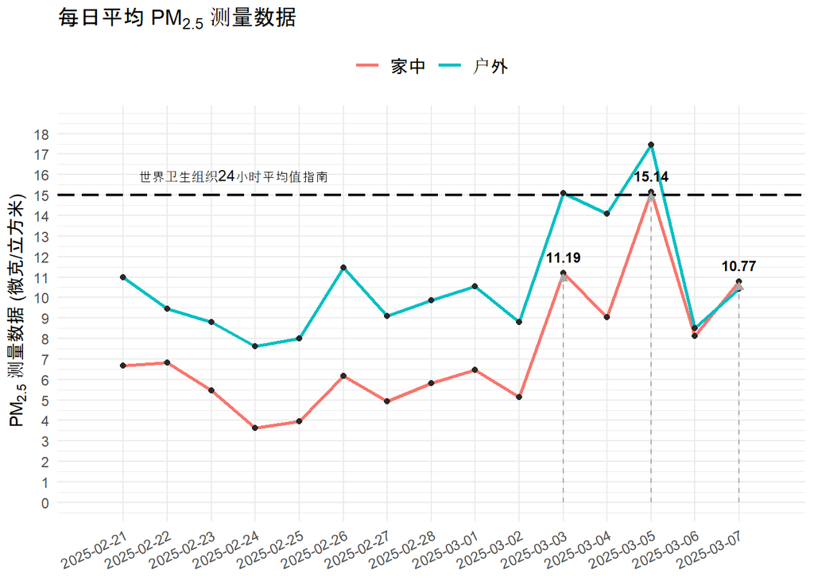

## 家中每小时平均 PM<sub>2.5</sub> 测量数据（工作日与周末对比）

本表展示了您家中 PM<sub>2.5</sub> 测量数据的统计汇总，按 Weekday 工作日（星期一至星期五）和 Weekend 周末（星期六与星期日）进行划分。描述性统计包括 PM<sub>2.5</sub> 测量数据的平均值(mean)、最小值(min)和最大值(max)。

家中 PM<sub>2.5</sub> 测量数据统计

| Day | PM<sub>2.5</sub> 测量数据 (微克/立方米) Mean | PM<sub>2.5</sub> 测量数据 (微克/立方米) Min | PM<sub>2.5</sub> 测量数据 (微克/立方米) Max |
| --- | --- | --- | --- |
| Weekend | 5.98 | 1.09 | 10.20 |
| Weekday | 7.74 | 0.01 | 31.97 |

该图展示了您家中在工作日（星期一至星期五）与周末（星期六与星期日）按小时划分的平均 PM<sub>2.5</sub> 测量数据水平。图中标出了三个您家中最高的PM<sub>2.5</sub>测量数据峰值。

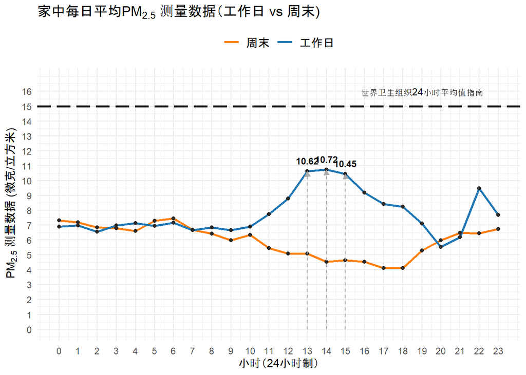

以下部分展示了您家中星期一至星期日的24小时平均 PM<sub>2.5</sub> 测量数据。

## 星期一

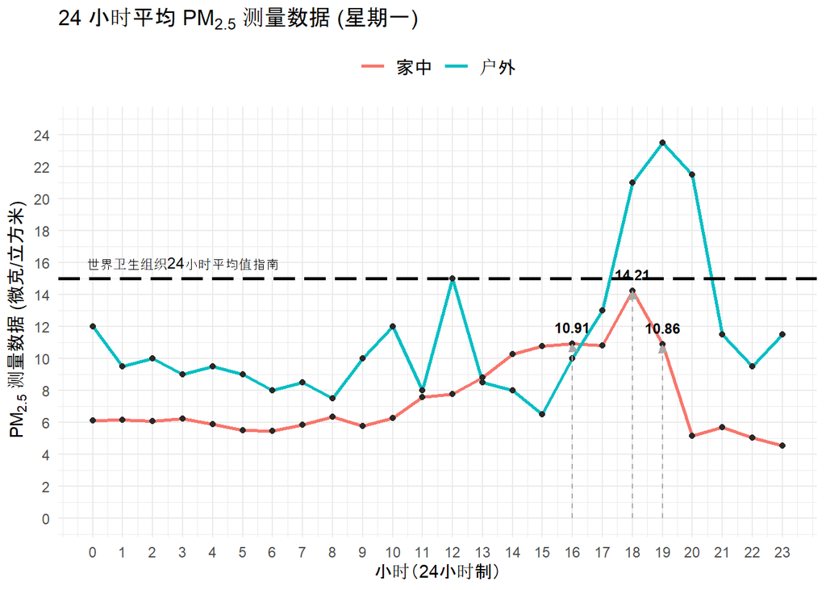

| Mean | PM<sub>2.5</sub> 测量数据 (微克/立方米) Min | PM<sub>2.5</sub> 测量数据 (微克/立方米) Max |
| --- | --- | --- |
| 7.41 | 4.54 | 14.21 |

## 星期二

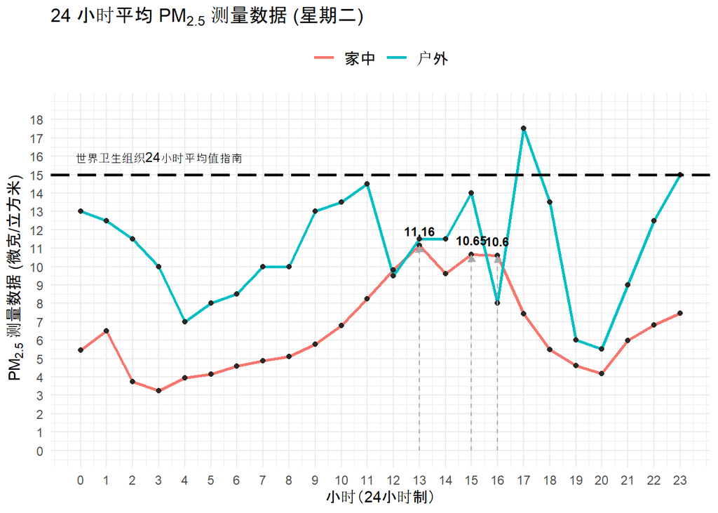

| Mean | PM<sub>2.5</sub> 测量数据 (微克/立方米) Min | PM<sub>2.5</sub> 测量数据 (微克/立方米) Max |
| --- | --- | --- |
| 6.51 | 3.24 | 11.16 |

## 星期三

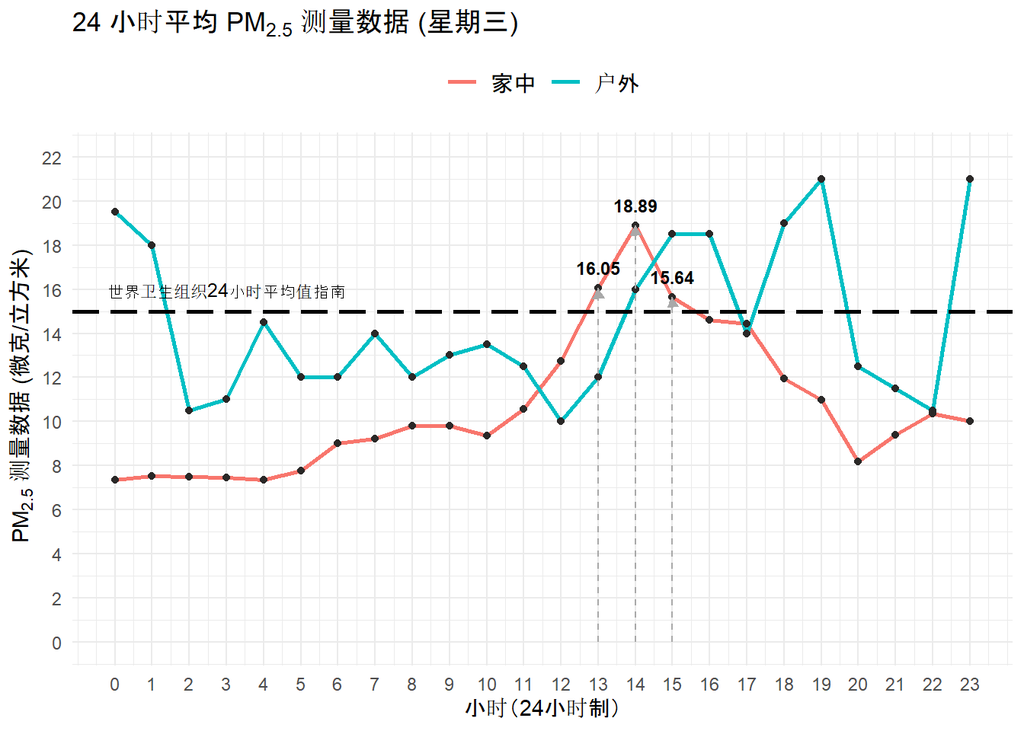

| Mean | PM<sub>2.5</sub> 测量数据 (微克/立方米) Min | PM<sub>2.5</sub> 测量数据 (微克/立方米) Max |
| --- | --- | --- |
| 10.66 | 7.36 | 18.89 |

## 星期四

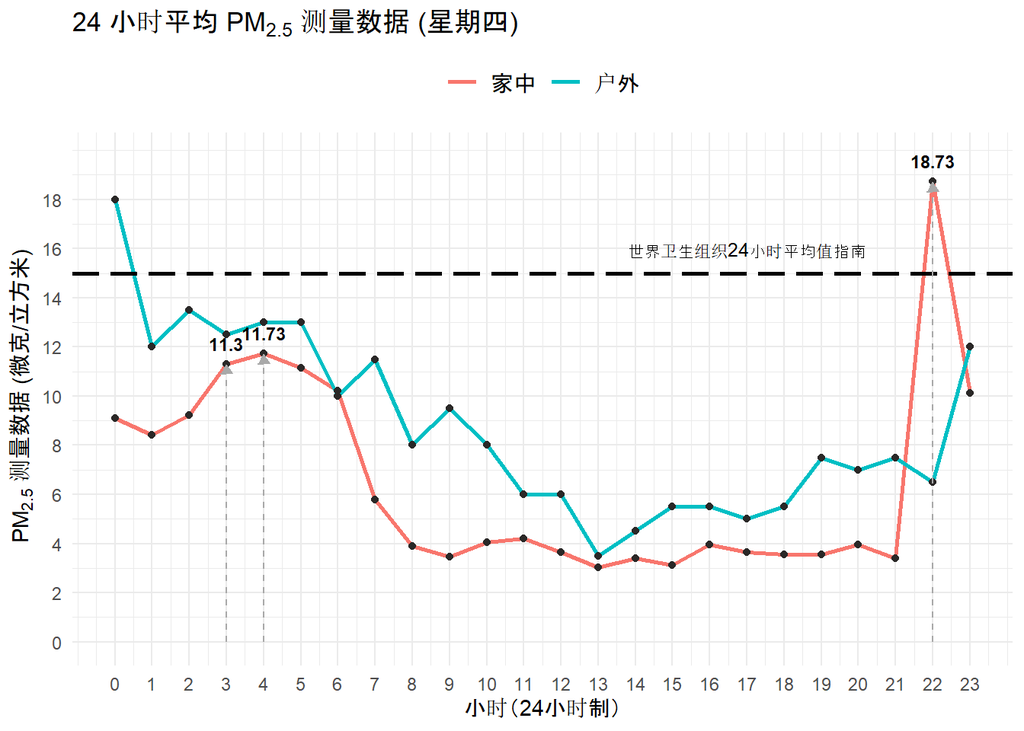

[output not shown]

## 星期五

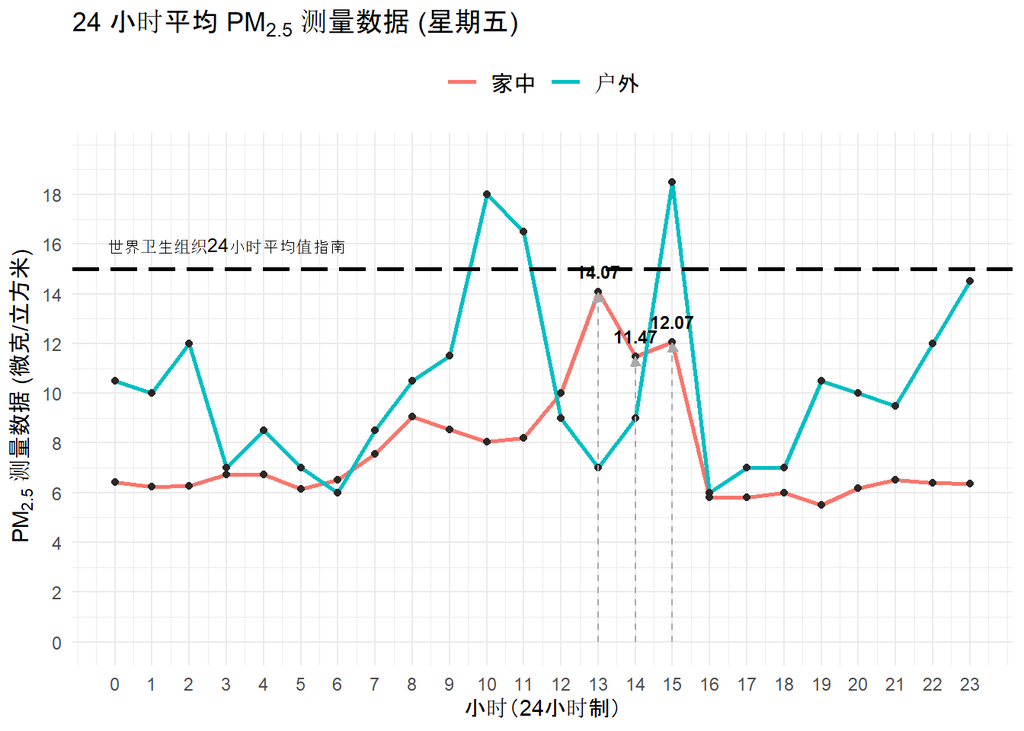

| Mean | PM<sub>2.5</sub> 测量数据 (微克/立方米) Min | PM<sub>2.5</sub> 测量数据 (微克/立方米) Max |
| --- | --- | --- |
| 7.61 | 5.51 | 14.07 |

## 星期六

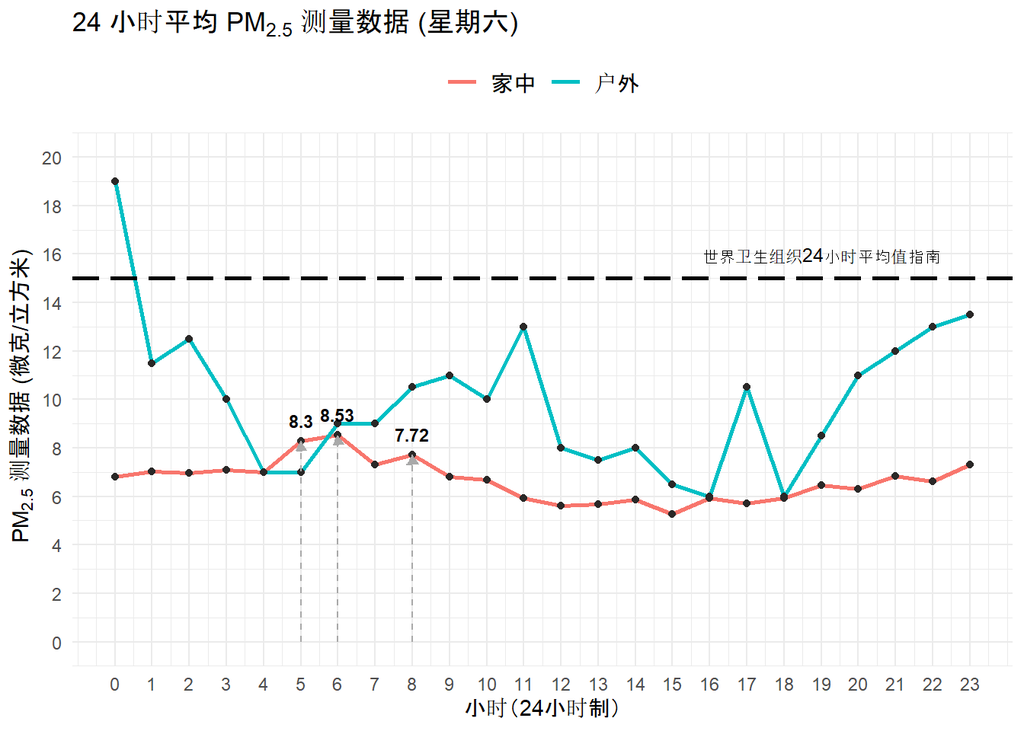

| Mean | PM<sub>2.5</sub> 测量数据 (微克/立方米) Min | PM<sub>2.5</sub> 测量数据 (微克/立方米) Max |
| --- | --- | --- |
| 6.65 | 5.26 | 8.53 |

## 星期日

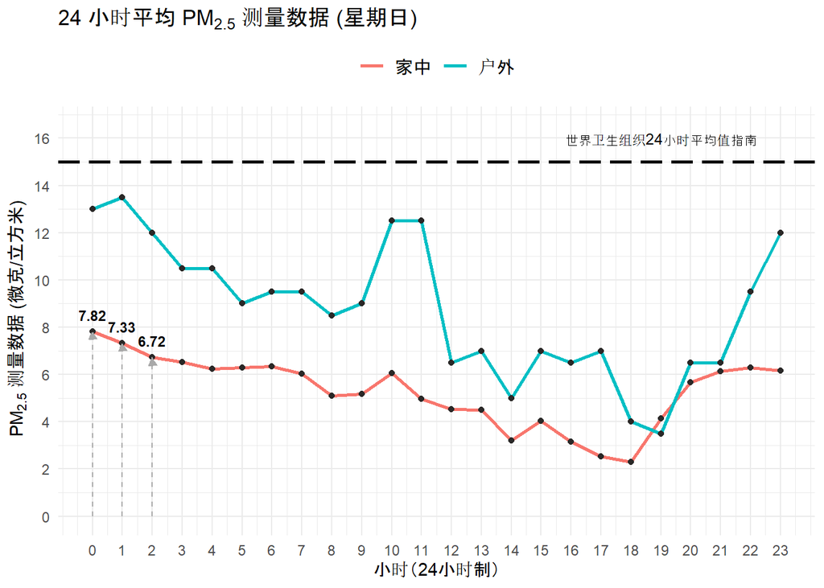

| Mean | PM<sub>2.5</sub> 测量数据 (微克/立方米) Min | PM<sub>2.5</sub> 测量数据 (微克/立方米) Max |
| --- | --- | --- |
| 5.3 | 2.29 | 7.82 |

## 联系信息

本报告中的数据和内容受版权保护，未经许可不得转载。 若需更多信息，请通过电子邮件联系我: ephanli@nus.edu.sg。

报告结束©